# Tutorial

## Introduction

In this vignette, we will show the basic usage of this package and demonstrate the convenience to do over-representation pathway analysis. The sample data used here is from Rigor & Reproductibility Core at the Texas A&M Health Science Center, Institute of Biosciences & Technology.

Originally, to perform pathway analysis, we need to query many online database to get pathway information, which is very time consuming. It also has stability issues that the database may not be accessed sometime. This package contains three common datasets locally (mouse, chicken, human pathway references). Although we may need to update them regularly, it saves a huge amount of time for each analysis. These data are stored in *data-raw/* and *data*.

## Grab DEGs and add annotation

Loading package into the R environment.

```r
library(quickpath)
```

Dataframe **gene_exp.diff** is the sample cuffdiff output. After reading the output of cuffdiff, we can easily get the DEGs (differential expressed genes) and add annotation to the genes. DEGs will be determined by the p value or q value with corresponding cutoff. If the parameter *out.name* is given, DEGs will be written into this file.

```r
data(gene_exp.diff)
print(dim(gene_exp.diff))
```

```
#> [1] 38203    14
```

```r
head(gene_exp.diff, n = 5)
```

```
#>              test_id            gene_id gene                    locus sample_1
#> 1 ENSMUSG00000000001 ENSMUSG00000000001    - chr3:108107279-108146146       q1
#> 2 ENSMUSG00000000003 ENSMUSG00000000003    -   chrX:77837900-77853623       q1
#> 3 ENSMUSG00000000028 ENSMUSG00000000028    -  chr16:18780446-18835261       q1
#> 4 ENSMUSG00000000031 ENSMUSG00000000031    - chr7:142575528-142578143       q1
#> 5 ENSMUSG00000000037 ENSMUSG00000000037    - chrX:161117192-161258213       q1
#>   sample_2 status   value_1   value_2 log2.fold_change. test_stat p_value
#> 1       q2     OK 31.292800 29.968300        -0.0623912 -0.164725  0.7761
#> 2       q2 NOTEST  0.000000  0.000000         0.0000000  0.000000  1.0000
#> 3       q2     OK  1.008170  0.889172        -0.1811990 -0.098150  0.8807
#> 4       q2     OK  0.597106  0.910721         0.6090240  0.503481  0.2340
#> 5       q2 NOTEST  0.106875  0.193166         0.8539180  0.000000  1.0000
#>    q_value significant
#> 1 0.999285          no
#> 2 1.000000          no
#> 3 0.999285          no
#> 4 0.999285          no
#> 5 1.000000          no
```

```r
deg = grab_degs_from_cuffdiff(gene_exp.diff, class = "mmu", criterion = "p_value", cut.off = 0.05)
print(dim(deg))
```

```
#> [1] 815  16
```

```r
head(deg[,c(1,4,8,9,10,11,12,13,15,16)],n = 5)
```

```
#>              gene_id                    locus   value_1  value_2
#> 1 ENSMUSG00000000078    chr13:5861488-5870393  6.909350  9.95204
#> 2 ENSMUSG00000000275  chr11:88999375-89020293 19.477500 28.93440
#> 3 ENSMUSG00000000290  chr10:77530251-77565708  5.729740  9.61269
#> 4 ENSMUSG00000000486 chr7:127214446-127218498  0.788340  2.18347
#> 5 ENSMUSG00000000489  chr15:79995899-80014808  0.599613  1.01245
#>   log2.fold_change. test_stat p_value  q_value external_gene_name
#> 1          0.526443  1.377720 0.01665 0.485810               Klf6
#> 2          0.570975  1.210770 0.03485 0.689127             Trim25
#> 3          0.746470  1.286350 0.01420 0.446043              Itgb2
#> 4          1.469740  0.885553 0.01885 0.514554              Sept1
#> 5          0.755745  1.148900 0.04690 0.774587              Pdgfb
#>                                                                       description
#> 1                       Kruppel-like factor 6 [Source:MGI Symbol;Acc:MGI:1346318]
#> 2               tripartite motif-containing 25 [Source:MGI Symbol;Acc:MGI:102749]
#> 3                               integrin beta 2 [Source:MGI Symbol;Acc:MGI:96611]
#> 4                                    septin 1 [Source:MGI Symbol;Acc:MGI:1858916]
#> 5 platelet derived growth factor, B polypeptide [Source:MGI Symbol;Acc:MGI:97528]
```

As you can see, we grab DEGs based p value and add *external_gene_name* and *description* based on *gene_id*.

## Hypergeometric test

After getting DEGs, we want to know the changes in each pathway. We choose to perform a hypergeometric test, which is equivalent to one-tailed version of Fisher’s exact test. We utilize the R package *parallel* to speed up our analysis. This is the main function in our package.

```r
sig.genes = deg$external_gene_name
path_res = pathway_analysis(sig.genes, class = "mmu")
```

```
#> [1] "sig genes in pathway: 381/8558"
#> [1] "Inference part is Done."
```

```r
head(path_res[[1]])
```

```
#>             name
#> 4  path:mmu00040
#> 5  path:mmu00051
#> 7  path:mmu00053
#> 9  path:mmu00062
#> 10 path:mmu00071
#> 12 path:mmu00100
#>                                                               path         pval
#> 4  Pentose and glucuronate interconversions - Mus musculus (mouse) 0.0006215702
#> 5           Fructose and mannose metabolism - Mus musculus (mouse) 0.0040557603
#> 7         Ascorbate and aldarate metabolism - Mus musculus (mouse) 0.0009988316
#> 9                     Fatty acid elongation - Mus musculus (mouse) 0.0004199621
#> 10                   Fatty acid degradation - Mus musculus (mouse) 0.0062652621
#> 12                     Steroid biosynthesis - Mus musculus (mouse) 0.0001238970
#>           qval percentage
#> 4  0.015156750  0.2058824
#> 5  0.049181214  0.1714286
#> 7  0.019789352  0.2222222
#> 9  0.013312798  0.2187500
#> 10 0.068485797  0.1400000
#> 12 0.005610764  0.3157895
```

Just to emphasize, all the analysis is not limitted to mouse data. Next is an example to process chicken data.

```r
deg_egg = grab_degs_from_cuffdiff(gene_exp.diff_egg, class = "gga")
```

```
#> Cache found
```

```r
sig.genes = deg_egg$external_gene_name
path_res_egg = pathway_analysis(sig.genes, class = "gga")
```

```
#> [1] "sig genes in pathway: 119/4701"
#> [1] "Inference part is Done."
```

```r
pathway <- c("Purine metabolism", "PI3K-Akt signaling pathway",
             "AMPK signaling pathway", "Choline metabolism in cancer")
deg.list = extract_genes_by_pathway(pathway, deg, class = "mmu")
```

```
#> Start checking pathway names...
#> [1] "1/4"
#>                              path:mmu00230
#> "Purine metabolism - Mus musculus (mouse)"
#> [1] "2/4"
#>                                       path:mmu04151
#> "PI3K-Akt signaling pathway - Mus musculus (mouse)"
#> [1] "3/4"
#>                                   path:mmu04152
#> "AMPK signaling pathway - Mus musculus (mouse)"
#> [1] "4/4"
#>                                         path:mmu05231
#> "Choline metabolism in cancer - Mus musculus (mouse)"
#> All names are valid!
#> [1] "Purine metabolism has DEGs 3/136"
#> [1] "PI3K-Akt signaling pathway has DEGs 20/357"
#> [1] "AMPK signaling pathway has DEGs 6/126"
#> [1] "Choline metabolism in cancer has DEGs 6/99"
```

## Generating figures

When we want to compare different groups, it is easier to visulize it in a figure. Before that, let us prepare more data.

```r
deg_chow = grab_degs_from_cuffdiff(gene_exp.diff_chow, class = "mmu")
sig.genes = deg_chow$external_gene_name
path_res_chow = pathway_analysis(sig.genes, class = "mmu")
```

```
#> [1] "sig genes in pathway: 229/8558"
#> [1] "Inference part is Done."
```

```r
deg_e105 = grab_degs_from_cuffdiff(gene_exp.diff_e105, class = "mmu")
sig.genes = deg_e105$external_gene_name
path_res_e105 = pathway_analysis(sig.genes, class = "mmu")
```

```
#> [1] "sig genes in pathway: 861/8558"
#> [1] "Inference part is Done."
```

```r
deg_e95 = grab_degs_from_cuffdiff(gene_exp.diff_e95, class = "mmu")
sig.genes = deg_e95$external_gene_name
path_res_e95 = pathway_analysis(sig.genes, class = "mmu")
```

```
#> [1] "sig genes in pathway: 344/8558"
#> [1] "Inference part is Done."
```

We can easily see the percentage of DEGs or p value for each pathway from different comparisons by utilizing the function *fig_path*. This is based on R package *ggplot2*. If *out.name* is specified, the figure will be saved into this file. You can also adjust several common parameters such as *height*, *width* and *res*.

```r
list.info = list(path_res[[2]], path_res_chow[[2]], path_res_e95[[2]], path_res_e105[[2]])
path.ids = check_pathway_name(pathway, class = "mmu")
```

```
#> Start checking pathway names...
#> [1] "1/4"
#>                              path:mmu00230
#> "Purine metabolism - Mus musculus (mouse)"
#> [1] "2/4"
#>                                       path:mmu04151
#> "PI3K-Akt signaling pathway - Mus musculus (mouse)"
#> [1] "3/4"
#>                                   path:mmu04152
#> "AMPK signaling pathway - Mus musculus (mouse)"
#> [1] "4/4"
#>                                         path:mmu05231
#> "Choline metabolism in cancer - Mus musculus (mouse)"
#> All names are valid!
```

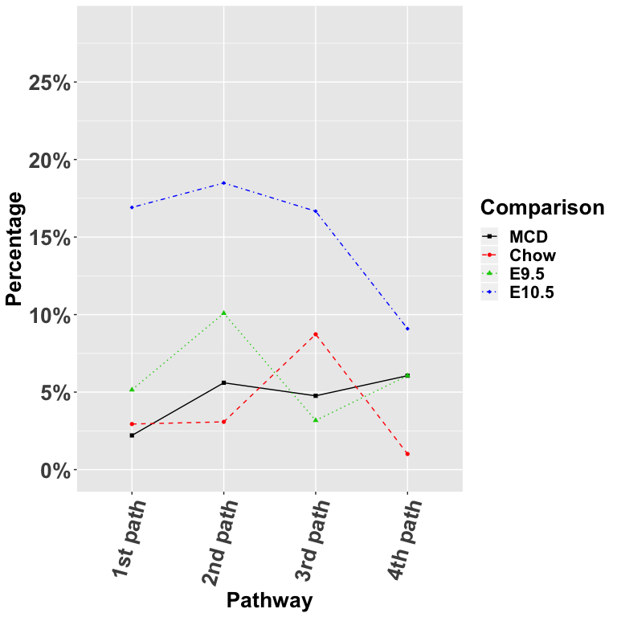

```r
group.info = c("MCD","Chow","E9.5","E10.5")
path.names = c("1st path","2nd path","3rd path","4th path")
fig_path(path.ids, list.info, group.info, criterion = "percentage", path.names = path.names)
```

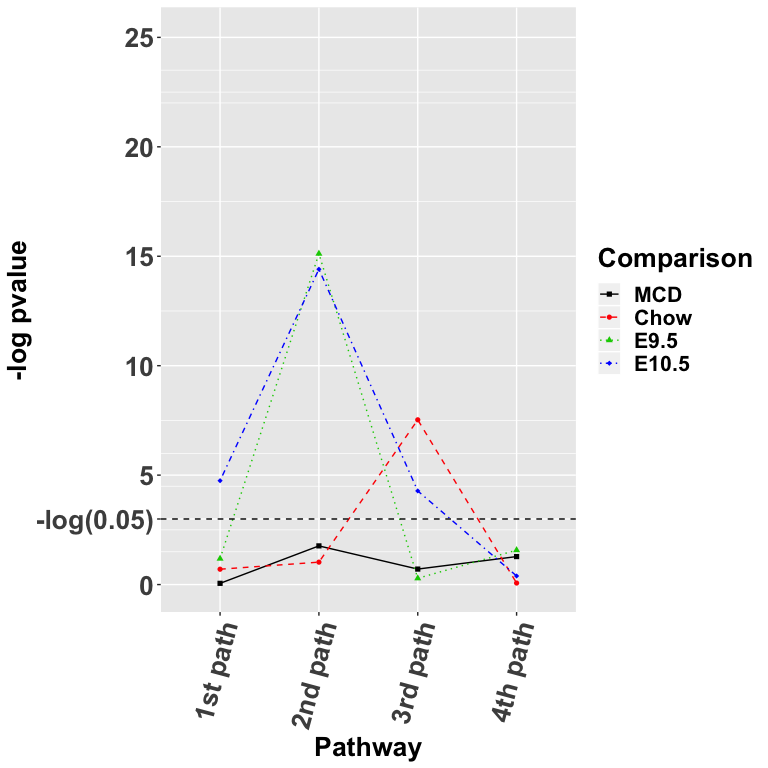

```r
fig_path(path.ids, list.info, group.info, criterion = "pval", path.names = path.names)
```

## Extension to other data type

Although this package is designed mainly for RNA-seq data, it also has the capacity to deal with other data type, such as DNA methylation sequencing data. Most of the analysis above is based on DEGs and pathway analysis result. Here, for DNA methylation data, we can easily change to DMRs (differential methylated regions) and pathway analysis result. For example, we simply call one gene with at least one DMR is a methylated gene. Since the background gene sets for RNA-seq and DNA methylation-seq are different, we need to account for that. There is a variantion of pathway analysis called *pathway_analysis_meth* with an extra *total.genes* input, which has the capacity to do that. I will not use real examples below, since the dataset is too large to include in a package.

```r
total.genes = mmu_genes_pathways$gene.symbol
deg = grab_degs_from_cuffdiff(gene_exp.diff, class = "mmu", criterion = "p_value", cut.off = 0.05)
sig.genes = deg$external_gene_name
meth_path_res = pathway_analysis_meth(sig.genes,total.genes, class = "mmu")
```

```
#> [1] "sig genes in pathway: 381/8558"
#> [1] "Inference part is Done."
```

Other analysis are mainly based on the pathway analysis result, which follows from previous procedure.